# PSY 5939: Longitudinal Data Analysis

# 1 Adding predictors

# 1.1 Predictors of growth

# 1.1.1 Predictors of growth

Mixed models can have predictors at different levels

- Predictors at level 2: **Time invariant** predictors = don’t change
  - At the level of the **participant**
  - Same value at every measurement occasion
- Predictors at level 1: **Time varying** predictors = change over time
  - At the level of the **measurement occasion**
  - Have a (potentially) different value at each measurement occasion

Level 2 predictors are easy, but level 1 predictors are a bit more complex

# 1.1.2 Level 2 predictors

Time invariant predictors **don’t** change with time

Go in the level 2 equation

$$\pi_{0i} = \beta_{00} + \beta_{01} (L2PRED_i) + r_{0i}$$

$$\pi_{1i} = \beta_{10} + \beta_{11} (L2PRED_i) + r_{1i}$$

# 1.1.3 More on level 2 predictors

If your level 2 predictors are dummy coded (0, 1), enter them as is

- Otherwise, **grand mean center** them

Remember that level 2 predictors lead to stealth interactions (time * L2 predictor) in the combined model

- **Always** write out the combined model

# 1.2 Level 1 predictors

# 1.2.1 Level 1 predictors

Time varying predictors **do** change over time

- Level 1 predictors go in the level 1 equation

Attitudes, substance use, stress, etc.

Complicated because contain **confounded** information:

- Level 1 information about measurement occasion
- Level 2 information about the average value for participant

Tease apart those two pieces of information (unconfound them) using different types of **centering**

# 1.2.2 Level 1 predictors

Level 1:

$$Y_{ij} = \pi_{0i} + \pi_{1i} (time_{ij}) + \pi_{2i}(L1PRED_{ij})+ e_{ij}$$

Level 2:

$$\pi_{0i} = \beta_{00} + r_{0i}$$

$$\pi_{1i} = \beta_{10} + r_{1i}$$

$$\pi_{2i} = \beta_{20} + r_{2i}$$

Combined:

$$Y_{ij} = (\beta_{00} + r_{0i}) + (\beta_{10} + r_{1i}) (time_{ij}) + (\beta_{20} + r_{2i})(L1PRED_{ij})+ e_{ij} =$$
$$\beta_{00} + \beta_{10}(time_{ij}) + \beta_{20}(L1PRED_{ij}) + r_{0i} + r_{1i}(time_{ij}) + r_{2i}(L1PRED_{ij}) + e_{ij}$$

# 1.2.3 Centering a level 1 predictor (not *time*)

There are 3 options for centering a level 1 predictor:

1. Center at a specific value
   - We do this with the *time* predictor
2. Center at the **grand mean** of all observations
   - This is just like mean centering in linear regression
   - **Grand mean centering (GMC)**
3. Center each cluster at the **mean of the cluster**
   - NEW – We have not done this yet
   - **Centering within cluster (CWC)**

# 1.2.4 Grand mean centering (GMC)

The grand mean is the average of **all** observations

- 100 participants, each measured 4 times = 400 observations
- Add up all 400 values of the variable, divide by 400
- Subtract this grand mean from all observations

As in linear regression, this type of centering doesn’t change the relationships among **variables** or among **people**

Just moves variables so that they have a mean of 0.

# 1.2.5 Grand mean centering (uncentered)

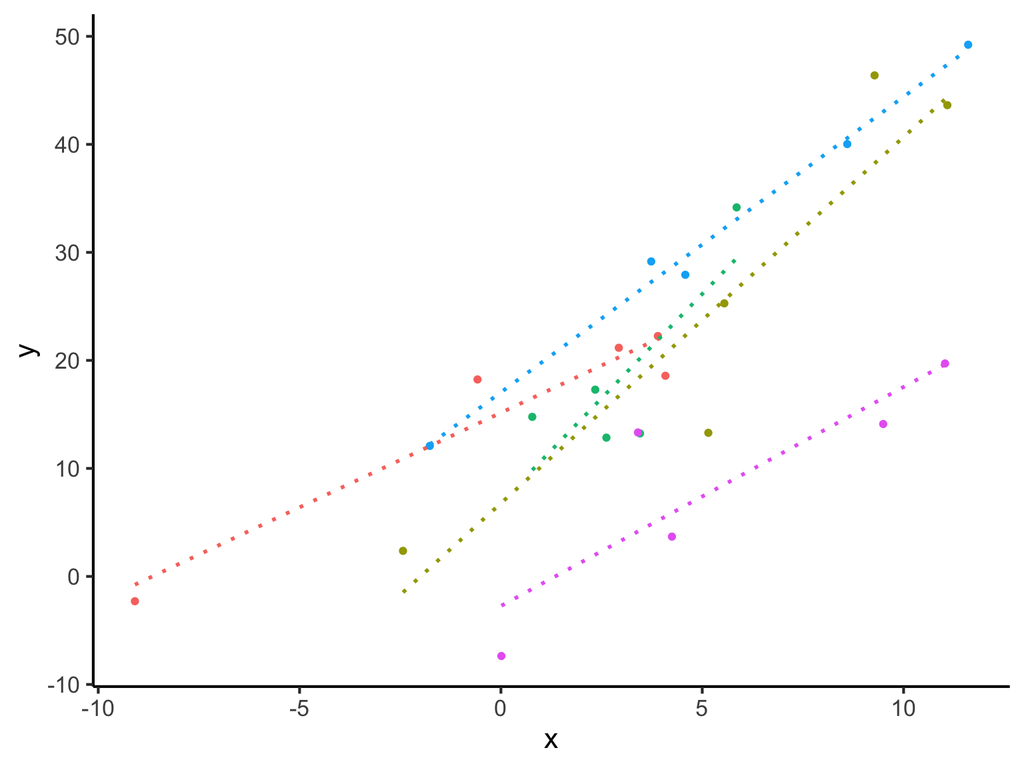

# 1.2.6 Grand mean centering (centered)

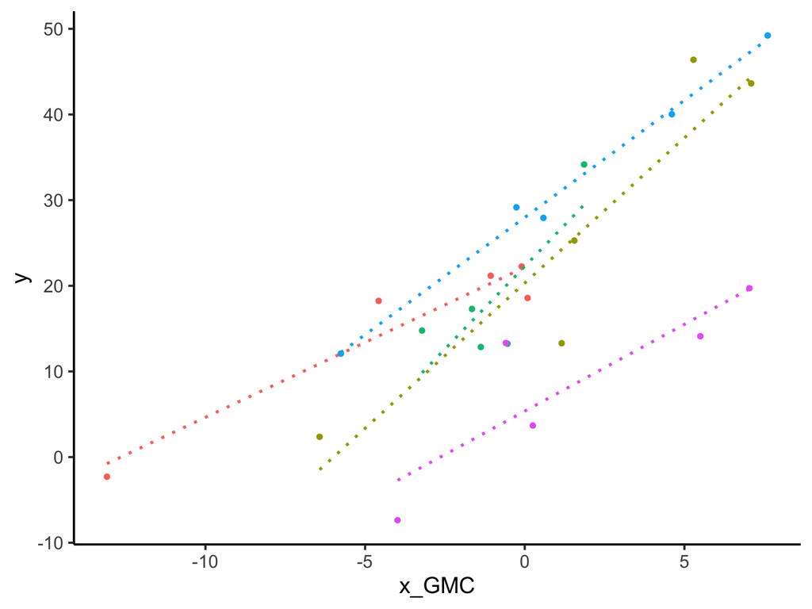

# 1.2.7 Grand mean centering (centered)

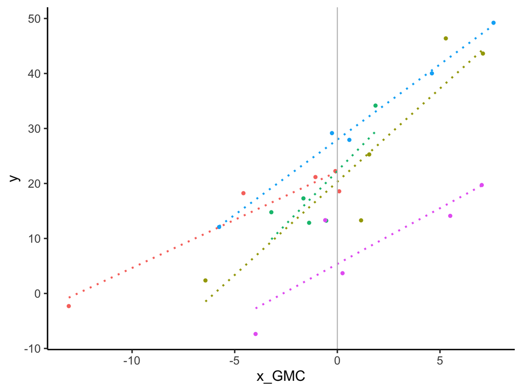

# 1.2.8 Centering within cluster (CWC)

Each cluster is centered around their **own cluster mean**

Here, each person is centered around **their personal mean** on the L1 predictor

- 100 participants, each measured 4 times = 400 observations
- **For each person**, calculate the mean of their 4 observations
- **For each person**, subtract *their mean* from their observations

This type of centering changes the relationships among variables

- Before CWC: Some clusters high on the predictor, some low on the predictor
- After CWC: All clusters have the same mean on the predictor

# 1.2.9 Centering within cluster (uncentered)

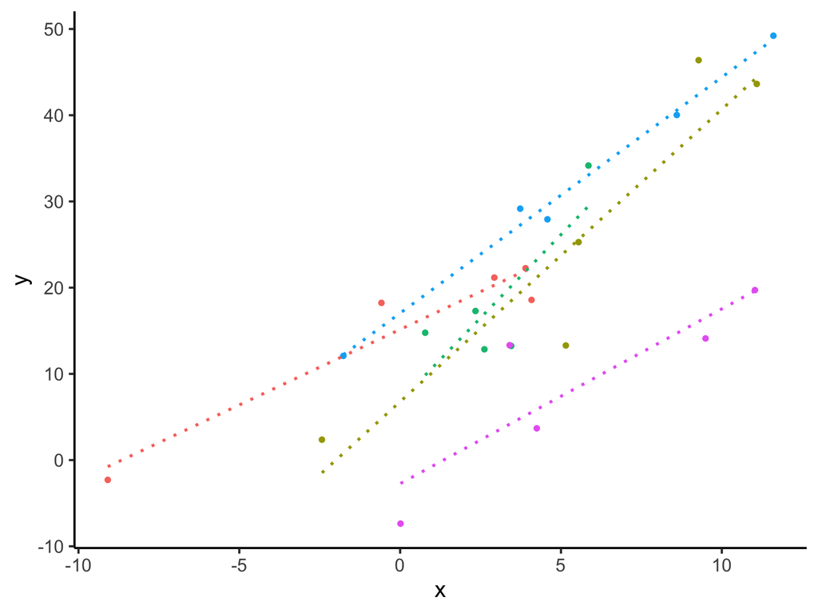

# 1.2.10 Centering within cluster (centered)

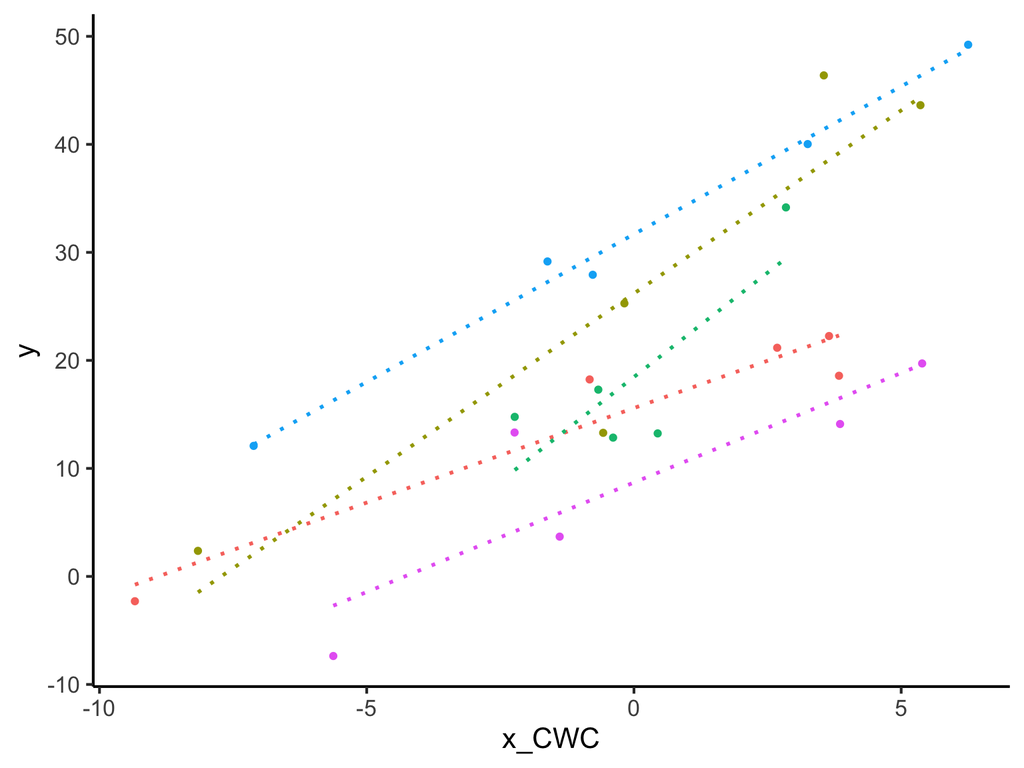

# 1.2.11 Centering within cluster (centered)

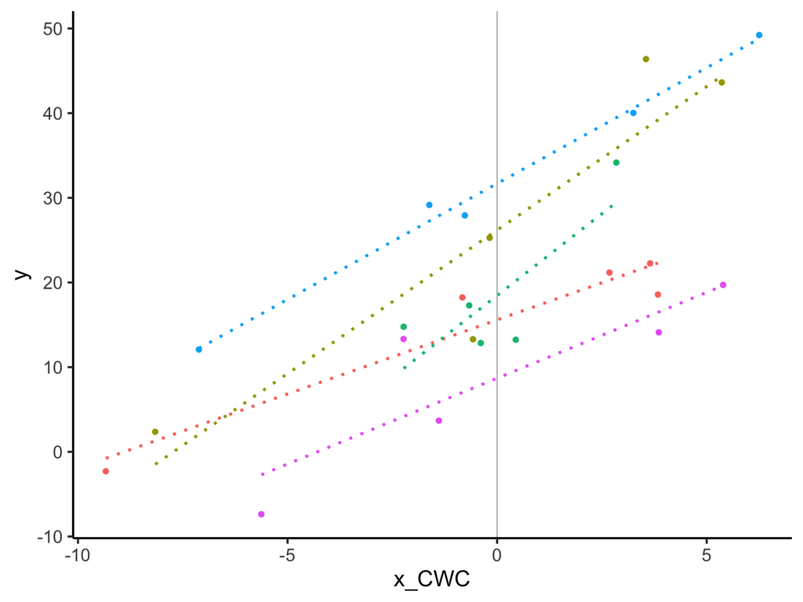

# 1.2.12 GMC vs. CWC

Centering changes the **context** for the different clusters (level 2 units)

GMC maintains differences **between people**

- What is a person like compared to **other** people?

CWC lines all the clusters up at their respective means on the L1 predictor and eliminates differences **between people (L2)**

- What are people like compared to their **own** mean?

**Different contexts** means **different interpretations** for both level 1 and level 2 predictors

Which type of centering depends (to some degree) on the specific research question

- See Kreft, de Leeuw, & Aiken (1995); Peugh & Enders (2005); Enders & Tofighi (2007); Rights, Preacher, & Cole (2019)

# 1.2.13 Additional complexity: Level 2 means of level 1 variables

What if the level 2 means of the level 1 variables are of interest?

- Cross-sectional: Person level SES (L1) aggregated at the school (L2)
- Longitudinal: Observation level depression (L1) aggregated at the person (L2)
- These types of situations are sometimes called “contextual effects” because you want to know about the level 1 observation in the **context** of level 2

Contextual effects model

- Center within cluster (CWC), which removes the cluster means
- Then include the mean of the level 1 variable for each level 2 unit as a level 2 predictor
- Refer to Enders & Tofighi (2007); Rights, Preacher, & Cole (2019) for more information

# 1.2.14 Additional complexity: Ecological fallacy

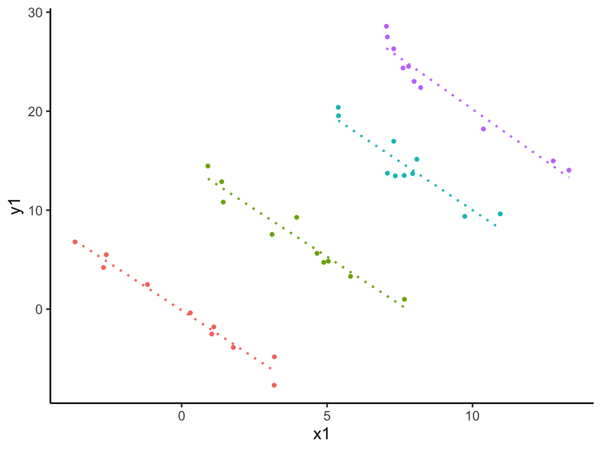

# 1.2.15 Additional complexity: Ecological fallacy

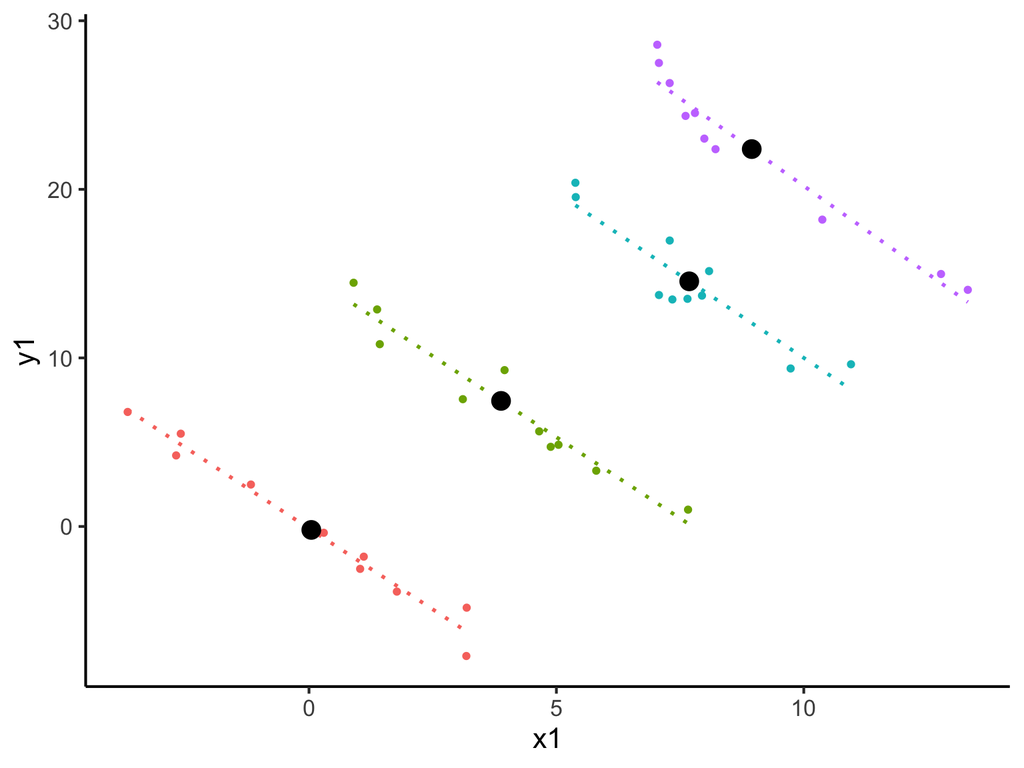

# 1.2.16 GMC vs. CWC summary 1

Use GMC when:

- Only level 2 variables in the model
- Including interactions between level 2 variables

# 1.2.17 GMC vs. CWC summary 2

Use CWC when:

- Interest is level 1 variable (or time)
- Interactions between level 1 variables
- Cross-level interactions between level 1 and level 2 variables
- Interested in level 2 variable while controlling for level 1 variable (Rights et al. vs Enders)

# 1.2.18 GMC vs. CWC example

L1 predictor: stress

L2 predictor: group

- Research question: Group, controlling for stress
  - Grand mean centering - Maintain level 2 differences (Enders)
  - Center within cluster - Unconfound level 1 and level 2 effects (Rights et al.)
- Research question: Interaction of group and stress
  - Centering within cluster - Effect of stress is unconfounded with group effect
- Research question: Contextual effect (how does the effect of stress vary across groups?)
  - Centering within cluster - Effect of stress is unconfounded with group effect
  - Include each person’s level 2 stress mean as a level 2 predictor

# 2 Statistical Inference

# 2.1 Interpretation

# 2.1.1 Fixed effects

Interpret as linear regression coefficients

- Pay close attention to the intercept and centering
- Linear slope is the change per 1 time unit
  - Nonlinear change is important but harder to interpret
- Average effect (averaged across all participants)

# 2.1.2 Random effects

Think carefully about which random effects you want to include

- Intercept, slope, etc.

Random effects are **variability in individuals**

- Intercept variance is how much individuals vary in their intercepts
- Slope variance is how much individuals vary in their change

# 2.2 Tests of significance

# 2.2.1 Tests of significance

Tests of the **fixed** effects

- Likely have an $F$ distribution (/ $t$ distribution)
- But it’s unclear what the degrees of freedom for that $F$ are
- More on that in a minute

Tests of **random** effects

- Random effects are normally distributed (see previous lectures)
- Usually (2 sided) $z$ test
- Variance can only be > 0, so divide 2-sided $p$-values by 2

# 2.3 Degrees of freedom

# 2.3.1 Degrees of freedom

**Degrees of freedom** are how much information is left over after we calculate quantities that we need

- For example: Standard deviation is divided by $N - 1$ because we “used up” 1 degree of freedom to calculate the mean (which we need to know in order to calculate the standard deviation)

Degrees of freedom are about how much **information** you’re **really** basing your calculations on

- You’ve already used up some of the information (data) to calculate things, and you can’t re-use it
- We care about degrees of freedom because they determine the critical values for our statistical tests

# 2.3.2 Degrees of freedom for linear regression: easy!

For the F-test in the ANOVA table ($p, N - p - 1$):

- Numerator df = # predictors = $p$
- Denominator df = # subjects - # predictors $- 1$ = $N - p - 1$

For t-tests of individual regression coefficients ($N - p - 1$):

- “Numerator df” = $1$
- Denominator df = # subjects - # predictors $- 1$ = $N - p - 1$

# 2.3.3 Degrees of freedom for linear regression: easy!

Number of subjects is how many (independent) pieces of information we have ($N$)

- We estimate one regression coefficient for each predictor ($p$)
- We estimate one mean / intercept ($1$)

Denominator df is how many independent pieces of information are **left over** after that

# 2.3.4 Degrees of freedom for mixed models: hard!!!

Premise for mixed models:

- Observations are **not** independent
- Now we don’t have N independent pieces of information
- We have fewer - **but how many fewer???**

The number is between # of clusters (people) and the total # of observations

- There are a number of different ways to calculate that
- Different programs have different methods and defaults

# 2.3.5 Degrees of freedom options: example

$N$ = total number of observations (roughly, times * people)

$k$ = total number of clusters (here, people)

$p$ = number of predictors

Example:

100 participants, each measured 4 times, with 3 predictors

- $N$ = 400
- $k$ = 100
- $p$ = 3

# 2.3.6 Degrees of freedom options: example

| Degrees of freedom | Calculation | Example value | Notes |
| --- | --- | --- | --- |
| Between-within | $k - p$ | 100 - 3 = 97 | $^1$ |
| Containment | $N - k$ | 400 - 100 = 300 | $^2$ |
| Residual | $N - p$ | 400 - 3 = 397 |  |
| Satterthwaite | Pooled $^3$ | Complicated | $^4$ |
| Kenward-Rogers | Based on Satterthwaite | Complicated |  |
| R `lme` | none | none |  |

$^1$ SAS mixed repeated default  
$^2$ SAS mixed random default  
$^3$ Weighted based on the variance of the predictor then pooled  
$^4$ SPSS mixed default (and only option)

# 2.3.7 Degrees of freedom caveats

**Idea**: Sampling distribution is $F$ distributed with some df

- But how many, given the non-independence?
- We don’t know, so we appromiximate it

# 2.3.8 Degrees of freedom caveats

**Good news**: If your sample is pretty large, it doesn’t matter much

Similar critical values

Between-within: $F_{crit}(3, 97) = 2.69839758$

Containment: $F_{crit}(3, 300) = 2.63470080$

Residual: $F_{crit}(3, 397) = 2.62870954$

**BONUS**: R `lme` package claims they aren’t F distributed at all - recommends **bootstrap**

# 2.4 Bootstrapping

# 2.4.1 What is bootstrapping?

**Nonparametric** method to construct confidence intervals

**Nonparametric** means that we don’t make assumptions about the sampling distribution of the parameter we’re interested in

- No assumptions of an $F$ distribution or a $z$ distribution

Previously, you’ve used a lot of **parametric** methods to construct confidence intervals

- Linear regression assumes that the sampling distribution of the regression coefficient follows a $t$ distribution
- Which it pretty much does if you mostly meet the assumptions of regression
- The $t$ distribution is the (assumed) **theoretical** sampling distribution

# 2.4.2 Why bootstrap here?

For mixed models, it’s less clear what theoretical sampling distribution (if any) the fixed effects follow

If there’s not an obvious or clear theoretical distribution, go ahead and bootstrap

# 2.4.3 How does bootstrapping work?

1. Sample **with replacement** from your **observations**
- Each sample is the same size as your observed sample
2. Do this many many time (e.g., 1000+)
3. In each sample, **estimate your model** and **record the parameter of interest** (e.g., regression coefficient)
- These 1000+ values of the parameter you’re interested in are the **empirical sampling distribution** for the parameter
- Contrast with **theoretical** sampling distribution, which is based on some known distribution (e.g., $F$, $t$, $\chi^2$)

# 2.4.4 How does bootstrapping work?

Order the 1000+ empirical sampling distribution values from lowest value to highest value

- For a 95% confidence interval, $\alpha$ = .05
- Lower confidence limit = 2.5%ile (one-half $\alpha$ from the bottom)
- Upper confidence limit = 97.5%ile (one-half $\alpha$ from the top)

If the confidence interval does not include 0, the effect is significant at that alpha level

# 2.4.5 How do I bootstrap?

SPSS 22 or higher

- Moderately easy in some situations
- Works for random effects (G) mixed models but not repeated (R) mixed models

SAS

- A little more complicated
- Write or use a program

R

- Super easy

See code on Canvas for all 3 packages

# 2.4.6 Recommendations

What you do depends on the software you’re using

**SAS**: Satterthwaite with optional bootstrap (not the default)

- Good choice with unbalanced designs (unequal number of observations per person (L2 unit))

**SPSS**: Satterthwaite with optional bootstrap

- This is the only option, but it’s a pretty good one

**R**: Bootstrap or `lmerTest` package

- `lmerTest` gives Satterthwaite degrees of freedom

# 2.5 Other ways to test effects

# 2.5.1 Other ways to test effects

As an alternative to traditional $t$ / $F$ tests of individual coefficients

- Likelihood ratio test comparing models
- Requires some careful thought because more things change than you realize

**Question**: Is the linear slope significant?

- Compare model *with* linear slope:

$$Y_{ij} = \beta_{00} + \beta_{10} (Time_{ij}) + r_{0i} + r_{1i} (Time_{ij}) + e_{ij}$$

to model *without* linear slope:

$$Y_{ij} = \beta_{00} + r_{0i} + e_{ij}$$

# 2.5.2 Other ways to test effects

**A more refined question**: Is the linear slope significant, **assuming no random slope**?

- Compare model *with* linear slope (fixed effect) and *random intercept only*

$$Y_{ij} = \beta_{00} + \beta_{10} (Time_{ij}) + r_{0i} + e_{ij}$$

to model *without* linear slope (fixed effect)

$$Y_{ij} = \beta_{00} + r_{0i} + e_{ij}$$

- In this case, the only addition is the fixed effect of the linear slope ($\beta_{10}$)

# 3 Advantages and Disadvantages

# 3.1 Advantages and Disadvantages

# 3.1.1 Regression software

The mixed model framework is similar to linear regression, so it’s easy to understand and makes intuitive sense

But it quickly grows in complexity with added predictors

Not a lot a flexibility regarding variance structure

(Sometimes being able to tweak your variance structure is key to getting a growth model to run)

# 3.1.2 Missing data

**Outcome variable**

- Can have missing values
- Assume MAR
  - All variables related to missingness are in the model
- If MNAR: problems (but not just for mixed models)

**Predictor variable**

- Software drops the case
  - Make sure no missing on predictors, or use e.g. multiple imputation
- MNAR still a major problem

# 3.1.3 Limited extensions of the mixed model

**Change in multiple variables at once**

- Limited ability to do this, but see Baldwin et al. article (which is very complicated)

**Mixed models can predict growth or change over time**

- Measurement occasion (level 1) and individual (level 2) predictors

**Nonnormal outcomes**

- Mixed models become more difficult in unexpected ways when outcomes are non-normal

**Growth cannot predict other things in mixed models**

- How does the linear growth in alcohol use from ages 13 to 18 predict substance use problems at age 25?

**SEM framework and latent growth models** can include growth as a predictor, simultaneous growth of multiple processes, and other more complex models